+++ title = "Combining Multiple Single cell RNA-seq Datasets: Part II" author = "Zhen Li" date = 2018-10-24 +++

In this post, I will try to combine [Nowakowski et al., 2017](http://science.sciencemag.org/content/358/6368/1318) , BrainSpan and [Zhong et al., 2017](https://www.nature.com/articles/nature25980) datasets.

All of these datasets are publicly available. For more information, please visit the Resources page

First let's combine the Nowakowski and Brainsan datasets.

```r
df0.all <- MergeSeurat(df0.BS, df0.nowa,
                       min.cells = 10,
                       do.normalize = T,
                       scale.factor = 100000)
```

Normalize both datasets:

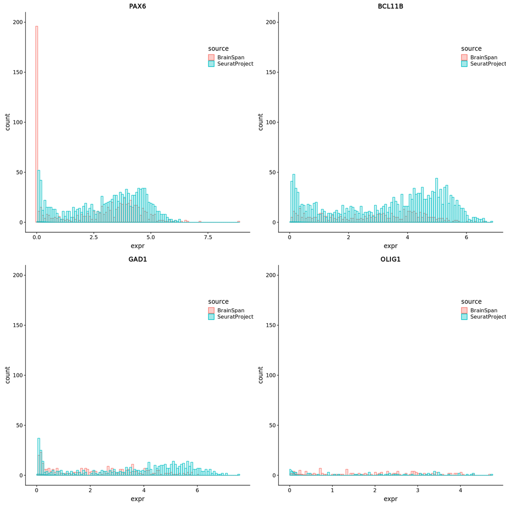

```r
p1 <- plotGeneDistr("PAX6",object1 = df0.all)
p2 <- plotGeneDistr("BCL11B",object1 = df0.all)
p3 <- plotGeneDistr("GAD1",object1 = df0.all)
p4 <- plotGeneDistr("OLIG1",object1 = df0.all)
plot_grid(p1, p2, p3, p4, nrow = 2)
```

Find highly variable genes to conduct PCA analysis:

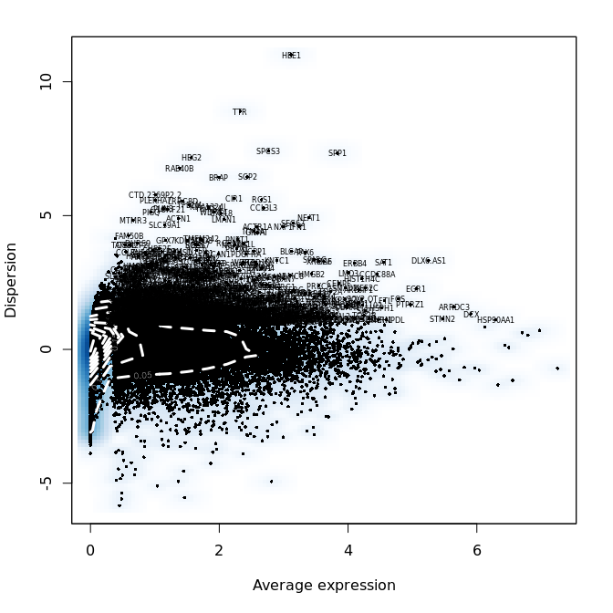

Run PCA:

```r
df0.all <- RunPCA(object = df0.all,
                  pc.genes=df0.all@var.genes,
                  pcs.compute = 30,
                  pcs.print = 1:10,
                  do.print = F,
                  genes.print = 10)
```

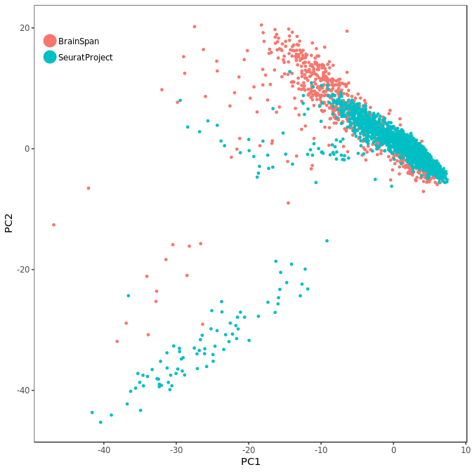

Pick significant PCs for tSNE and clustering analysis based on elbow plot:

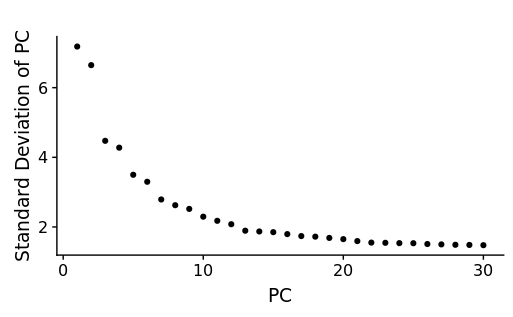

I chose 20 PCs for down stream analysis.

Run tSNE analysis:

```r
df0.all <- RunTSNE(df0.all,
               dims.use = 1:20,
               perplexity = 30,
               seed.use = 1)
df0.all <- FindClusters(object = df0.all,
                    reduction.type = "pca",
                    dims.use = 1:20,
                    resolution = 0.8,
                    print.output = 0,
                    save.SNN = F,
                    force.recalc = T)
```

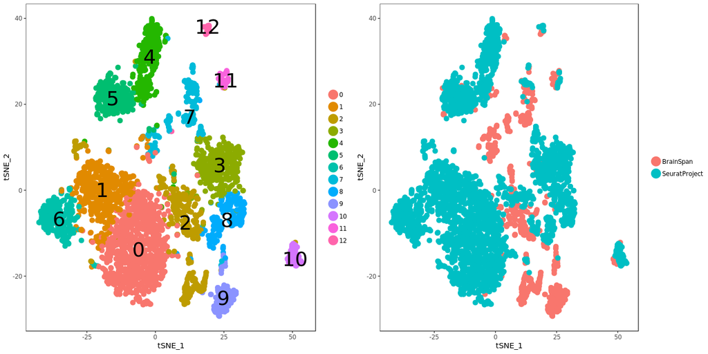

```r
p1 <- TSNEPlot(object = df0.all,
               pt.size = 3,
               do.label = T,
               label.size = 10,
               do.return = T)
p2 <- TSNEPlot(object = df0.all,
               group.by = "orig.ident",
               do.return = T,
               pt.size = 3)
plot_grid(p1, p2, ncol = 2)
```

```r
source("~/zhen/scripts/R/functions/markers.R")
markers <- unlist(sapply(markers,function(x){grep(x, rownames(df0.all@data), value = T)}))
```

```r
## Plot marker genes
temp <- df0.all@data[markers,]
ord <- order(df0.all@meta.data$res.0.8)
ColSideColors <- c(gg_color_hue(length(unique(df0.all@meta.data$res.0.8)))[as.numeric(as.factor(df0.all@meta.data$res.0.8))],
rainbow(2)[as.numeric(as.factor(df0.all@meta.data$orig.ident))])
ColSideColors <- matrix(data = ColSideColors, nrow = ncol(temp));
ColSideColors <- ColSideColors[ord, ];
colsep <- lapply(unique(df0.all@meta.data$res.0.8[ord]),
function(xx){length(which(df0.all@meta.data$res.0.8 == xx))});
colsep <- cumsum(unlist(colsep));
pairs.breaks <- seq(-2, 2, length.out=101);
```

```
Using scale="row" or scale="column" when breaks arespecified can produce unpredictable results.Please consider using only one or the other.
```

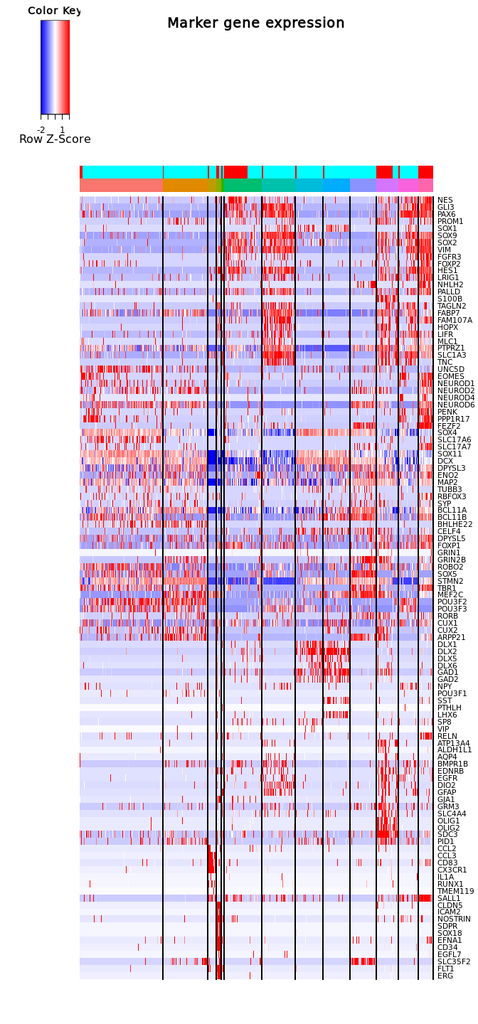

```r
heatmap.3(temp[, ord],
          breaks = pairs.breaks,
          #symbreaks = T,
          keysize = 0.8,
          main="Marker gene expression",
          col = gplots::bluered(100),
          symkey = F,
          cexRow=1, cexCol = 0.6,
          Rowv = F,
          Colv = F,#as.dendrogram(hca),
          ColSideColors = as.matrix(ColSideColors),
          ColSideColorsSize = 1,
          #RowSideColors = RowSideColors,
          dendrogram = "none",
          scale = "row",
          colsep = colsep,
          sepcolor = "black",
          labRow = rownames(temp),
          labCol = "",
          na.rm = F)
```

Add another dataset: Zhong et al. 2017

Merge Zhong et al dataset to the other two:

```r
df0.all <- MergeSeurat(df0.all, df0.zhong,
                       min.cells = 10,
                       do.normalize = T,
                       scale.factor = 100000)
```

```r
df0.all@meta.data$Time_point2[df0.all@meta.data$Time_point %in%
                                    c("5 pcw", "6 pcw", "8 pcw", "GW08", "GW09","GW10")] <- "W1"
df0.all@meta.data$Time_point2[df0.all@meta.data$Time_point %in%
                                    c("11", "13", "13.3","14","14.2","14.5","14.7","GW12","GW13", "GW16")] <- "W2"
df0.all@meta.data$Time_point2[df0.all@meta.data$Time_point %in%
                                    c("15", "16 pcw", "16.3","17.3","17.5","18.5","GW19")] <- "W3"
df0.all@meta.data$Time_point2[df0.all@meta.data$Time_point %in%
                                    c("19", "19 pcw", "20 pcw","20","21.5","22","GW23","GW26")] <- "W4"
df0.all@meta.data$Time_point2[df0.all@meta.data$Time_point %in% c("32")] <- "W5"
```

Regress out nUMI and different studies.

Find highly variable genes to conduct PCA analysis:

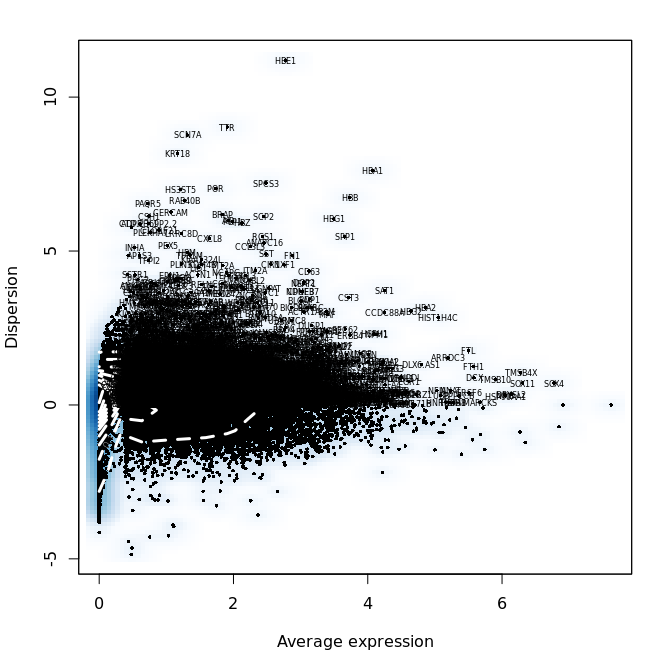

Run PCA:

```r
df0.all <- RunPCA(object = df0.all,
                  pc.genes=df0.all@var.genes,
                  pcs.compute = 30,
                  pcs.print = 1:10,
                  do.print = F,
                  genes.print = 10)
```

[output not shown]

Run tSNE analysis:

```r
df0.all <- RunTSNE(df0.all,
               dims.use = 1:20,
               perplexity = 30,
               seed.use = 1)
df0.all <- FindClusters(object = df0.all,
                    reduction.type = "pca",
                    dims.use = 1:20,
                    resolution = 0.8,
                    print.output = 0,
                    save.SNN = F,
                    force.recalc = T)
```

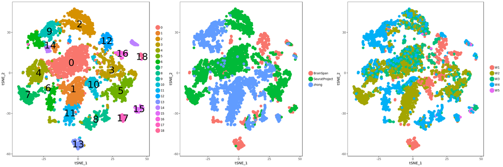

```r
source("~/zhen/scripts/R/functions/markers.R")
markers <- unlist(sapply(markers,function(x){grep(x, rownames(df0.all@data), value = T)}))
```

```r
## Plot marker genes
temp <- df0.all@data[markers,]
ord <- order(df0.all@meta.data$res.0.8)
ColSideColors <- c(gg_color_hue(length(unique(df0.all@meta.data$res.0.8)))[as.numeric(as.factor(df0.all@meta.data$res.0.8))],
rainbow(3)[as.numeric(as.factor(df0.all@meta.data$orig.ident))])
ColSideColors <- matrix(data = ColSideColors, nrow = ncol(temp));
ColSideColors <- ColSideColors[ord, ];
colsep <- lapply(unique(df0.all@meta.data$res.0.8[ord]),
function(xx){length(which(df0.all@meta.data$res.0.8 == xx))});
colsep <- cumsum(unlist(colsep));
pairs.breaks <- seq(-2, 2, length.out=101);
```

```
Using scale="row" or scale="column" when breaks arespecified can produce unpredictable results.Please consider using only one or the other.
```

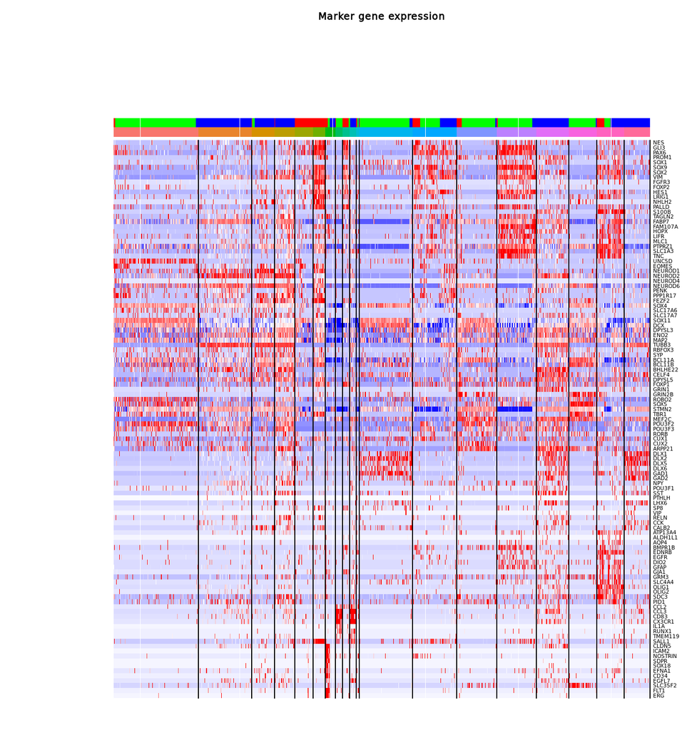

```r
heatmap.3(temp[, ord],
          breaks = pairs.breaks,
          key = F,
          #symbreaks = T,
          keysize = 0.8,
          main="Marker gene expression",
          col = gplots::bluered(100),
          symkey = F,
          cexRow=1, cexCol = 0.6,
          Rowv = F,
          Colv = F,#as.dendrogram(hca),
          ColSideColors = as.matrix(ColSideColors),
          ColSideColorsSize = 1,
          #RowSideColors = RowSideColors,
          dendrogram = "none",
          scale = "row",
          colsep = colsep,
          sepcolor = "black",
          labRow = rownames(temp),
          labCol = "",
          na.rm = F)
```